# Specs for Eivory’s App

Homer White

2024-04-04

## Aim of the App

The purpose of the app is to convince the reader that the household differ in how much wood they use per person in a day, i.e., that some households won’t use a lot of wood per person; others may use quite a bit per person.

When the reader understands this, she knows that the 57 daily measurements in our study cannot be viewed as a random sample of measurements from a “population” of all days in all households in the country. Instead the data will have to viewed as the result of a two part process:

1. Sampling 16 households at random from the population of all households that use the stoves, and then
2. sampling a certain number of days (at least three) for each households and measuring the per-capita wood usage for each day.

## Setup

Here is our data:

```r
get_house <- function(i) {
  vals <- read_excel(
    "../st_files/For Review_Ret_Justa_July KPT Complete_KPT_4day (1).xlsx",
    range = "I15:L15",
    sheet = paste0("HH", i, " Data"),
    col_names = FALSE
  ) %>%
    as.matrix() %>%
    t() %>%
    .[,1]
  vals <- vals[!is.na(vals)]
  data.frame(
    house = rep(i, length(vals)),
    wood = vals
  )
}

all_meas <-
  map_dfr(factor(1:16), get_house) %>%
  group_by(house) %>%
  mutate(mean_percap = mean(wood)) %>%
  mutate(deviation = wood - mean_percap)

DT::datatable(all_meas %>% select(house, wood))
```

|  | house | wood |
| --- | --- | --- |
| 1 | 1 | 4.786749762 |
| 2 | 1 | 5.202403542 |
| 3 | 1 | 5.172864812 |
| 4 | 1 | 6.06969271 |
| 5 | 2 | 4.601466898 |
| 6 | 2 | 5.515436944 |
| 7 | 2 | 4.31742106 |
| 8 | 2 | 4.667190671 |
| 9 | 3 | 2.29721166 |
| 10 | 3 | 1.281819939 |

[output cut: 47 more lines]

If households don’t differ in the amount of wood they use per-capita, then each number in the `wood` column could just as well have appeared in a row for other household. This means that the data could just as well have come scrambled randomly, like this:

```r
resample_data <- function() {
  rs <-data.frame(
    house = all_meas$house,
    wood = sample(
      all_meas$wood,
      size = length(all_meas$wood),
      replace = FALSE
    )
  )
}

DT::datatable(resample_data())
```

|  | house | wood |
| --- | --- | --- |
| 1 | 1 | 3.533475027 |
| 2 | 1 | 3.31748386 |
| 3 | 1 | 2.57406585 |
| 4 | 1 | 6.770303527 |
| 5 | 2 | 4.836398376 |
| 6 | 2 | 4.74958869 |
| 7 | 2 | 5.202403542 |
| 8 | 2 | 1.534078457 |
| 9 | 3 | 1.690596415 |
| 10 | 3 | 6.039376538 |

[output cut: 47 more lines]

Run the above code-chunk several times, and watch the values shuffle each time!

Now from the resampled data, we can compute the mean for each household. we can compare the resampled means with the household means of the original data.

Here is a function to make a density plot of the means, with a rug:

```r
density_with_rug <- function(df) {
  ggplot(df, aes(x = household_mean)) +
    geom_density(fill = "skyblue") +
    geom_rug() +
    xlim(c(0,8)) +
    ylim(c(0,1)) +
    labs(x = "household means of daily per-capita usage")
}
```

Here is a density plot for the actual 16 household means:

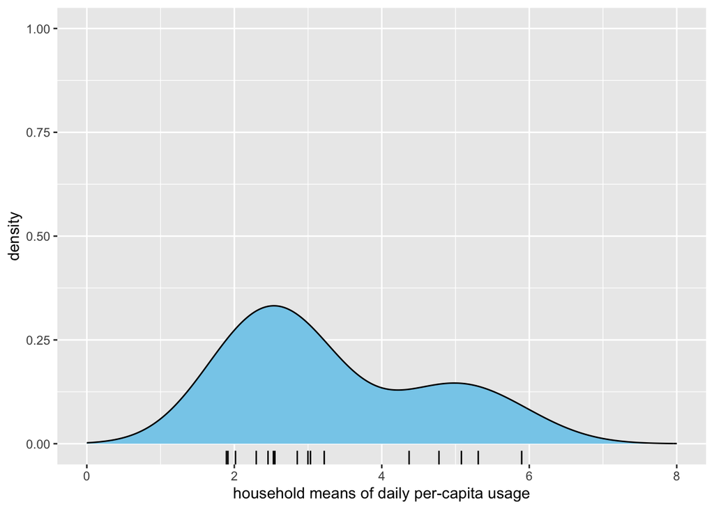

```r
sample_means <-
  all_meas %>%
  group_by(house) %>%
  summarise(household_mean = mean(wood))
density_with_rug(df = sample_means)
```

The following is a density plot of the 16 household means for randomly scrambled data:

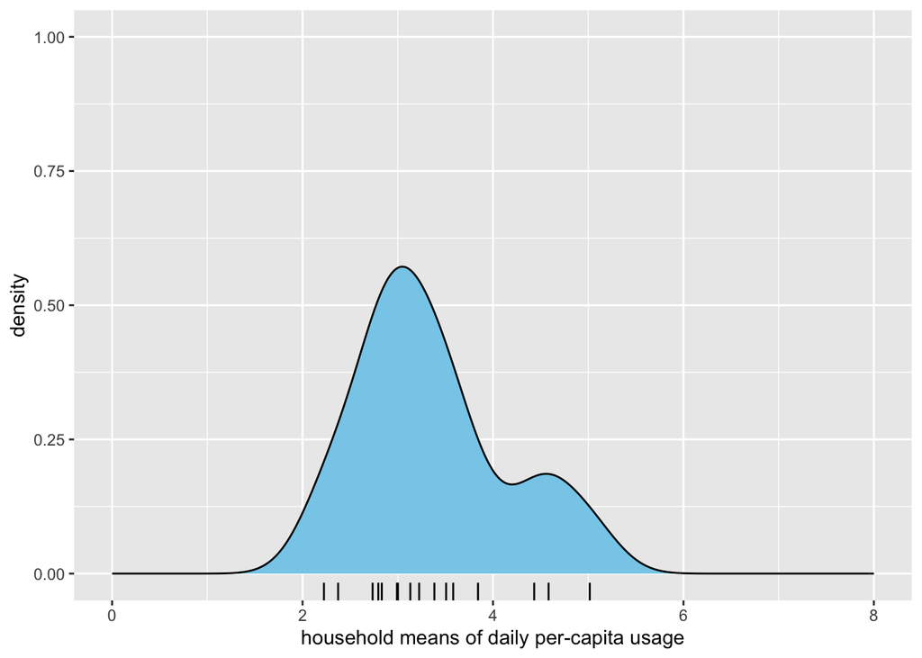

```r
rs_means <-
  resample_data() %>%
  group_by(house) %>%
  summarise(household_mean = mean(wood))
density_with_rug(df = rs_means)
```

Re-run the above code a few times. You will see that for scrambled data, the household means are much less spread apart than they are in the original data.

One can also compare things numerically. Here is a function to compute the mean and standard deviation of a vector of values:

```r
summary_stats <- function(vals) {
  c(
    mean = mean(vals),
    stdev = sd(vals)
  )
}
```

Here are the mean and standard deviation of the original 16 household means:

```r
summary_stats(vals = sample_means$household_mean)
```

```
##     mean    stdev
## 3.324635 1.317722
```

Run the code-chuck below a few times. You’ll see that for scrambled data the household means usually have a much smaller standard deviation.

```r
rs_means <-
  resample_data() %>%
  group_by(house) %>%
  summarise(household_mean = mean(wood))
summary_stats(vals = rs_means$household_mean)
```

```
##      mean     stdev
## 3.4063299 0.7437647
```

## App Specs

- Sidebar Panel
  - action button with id = “resample”
- Main Panel (two columns, equal width)
  - left column: a density plot, with rug, of the 16 household means in the actual data, and underneath the plot a statement of the mean and the standard deviation of these 16 means;
  - right column: a density plot, with rug, of the 16 household means in the resampled data, and underneath the plot a statement of the mean and the standard deviation of these 16 household means.

When the user pushes the Resample button, the `wood` column in the data is randomly scrambled, and a new density plot and statement of mean and standard deviation appear in the right column of the main panel.